# Linear Regression

Onyango Jack Ochieng

2024-03-03

```r
library(tidyverse)
```

```r
library(stats)
library(ggplot2)

x <- c(1, 1, 2, 2, 3, 3, 4, 4, 5, 5, 6, 6, 7, 7, 8, 8, 9, 9, 10, 10)
y <- c(38, 45, 43, 48, 47, 56, 61, 72, 75, 75, 58, 81, 66, 86, 72, 69, 83, 83, 79, 85)

df <- data.frame(x, y)
```

Let’s start by preparing various columns that will ease our operations

```r
df <- cbind(df, xSquared = df$x ^ 2)
df <- cbind(df, xy = df$x * df$y)

view(df)
```

Lets find the coefficient of correlation We will need to find x-mean(x) and y-mean(y)

```r
mean(df$x)
```

```
## [1] 5.5
```

```r
mean(df$y)
```

```
## [1] 66.1
```

```r
df<- cbind(df, XminusXbar=(df$x - mean(df$x)))
df<- cbind(df, YminusYbar=(df$y - mean(df$y)))
```

## Question 1

Draw the scatter plot

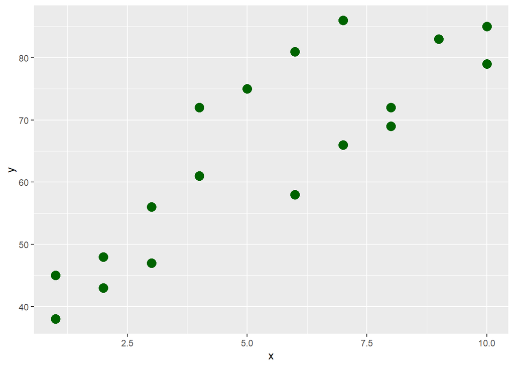

```r
ggplot(df, aes(x = x, y = y))+geom_point(color = "darkgreen", size = 4)
```

## Question 2

## Find the coefficient of Correlation and the coeficient of determination

```r
num<- sum(df$XminusXbar * df$YminusYbar)

den<- sqrt((sum(df$XminusXbar ^ 2) * sum(df$YminusYbar ^ 2)))

r<- num/den
r
```

```
## [1] 0.8547834
```

The coefficient ofdetermination is given by r squared

```r
rsquared<- r * r
cat("The coefficient of correlation is ",r ,"While the coefficient of determination is ",rsquared)
```

```
## The coefficient of correlation is  0.8547834 While the coefficient of determination is  0.7306547
```

Since our r is 0.8547834 we can say that their relationship is is good such that a shift in one likely to cause the other one to shift. But this is likely to affect approximately 73% of the data since our R squared is 0.7306547

## Question 3

## Draw a simple regression line of Y=a + bx + error term

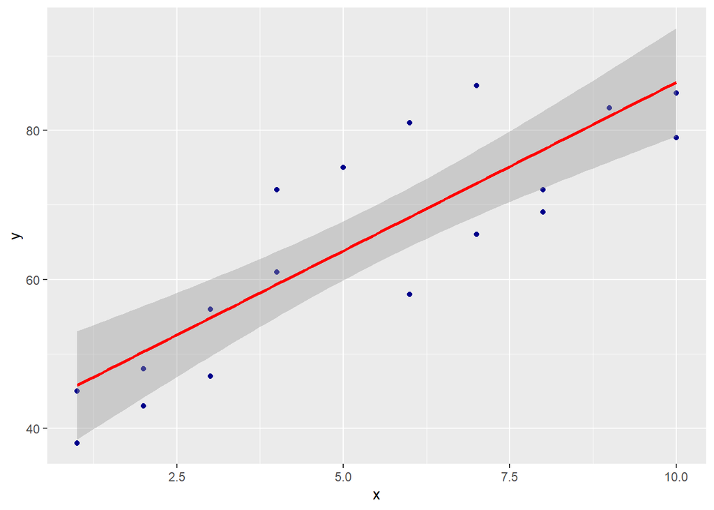

```r
model<- lm(y ~ x, data=df)
ggplot(df,aes(x=x,y=y))+
  geom_point(color="darkblue")+
  geom_smooth(method= "lm" , color="red")
```

```r
model<- lm(y ~ x, data=df)
```

## Question 4

## Find the residual

To find the residual, first we need to find the values of a and b a = mean of y - b*mean of x lets start by finding b

```r
Bnum1<- sum(df$xy)
Bnum2<- 20 * mean(df$x) * mean(df$y)

Bden1 <- sum(df$xSquared)
Bden2 <- 20 * ((mean(df$x))^2)
num <- Bnum1 - Bnum2
den <- Bden1 - Bden2

b <- num/den

cat("The numerator is: ",num ,"The denominator is: ",den, "The value of B becomes",b)
```

```
## The numerator is:  745 The denominator is:  165 The value of B becomes 4.515152
```

Now to find the value of a

```r
a <- (mean(df$y))-(b * (mean(df$x)))

a
```

```
## [1] 41.26667
```

residual = y - y Hat Lets find yHat yiHat = a + bxi for i = 1,2,…,20

```r
df<- cbind(df, yHat = a + (b* df$x))
df
```

```
##     x  y xSquared  xy XminusXbar YminusYbar     yHat
## 1   1 38        1  38       -4.5      -28.1 45.78182
## 2   1 45        1  45       -4.5      -21.1 45.78182
## 3   2 43        4  86       -3.5      -23.1 50.29697
## 4   2 48        4  96       -3.5      -18.1 50.29697
## 5   3 47        9 141       -2.5      -19.1 54.81212
## 6   3 56        9 168       -2.5      -10.1 54.81212
## 7   4 61       16 244       -1.5       -5.1 59.32727
## 8   4 72       16 288       -1.5        5.9 59.32727
## 9   5 75       25 375       -0.5        8.9 63.84242
## 10  5 75       25 375       -0.5        8.9 63.84242
## 11  6 58       36 348        0.5       -8.1 68.35758
## 12  6 81       36 486        0.5       14.9 68.35758
## 13  7 66       49 462        1.5       -0.1 72.87273
## 14  7 86       49 602        1.5       19.9 72.87273
## 15  8 72       64 576        2.5        5.9 77.38788
## 16  8 69       64 552        2.5        2.9 77.38788
## 17  9 83       81 747        3.5       16.9 81.90303
## 18  9 83       81 747        3.5       16.9 81.90303
## 19 10 79      100 790        4.5       12.9 86.41818
## 20 10 85      100 850        4.5       18.9 86.41818
```

Now to find the residual or the standard error

```r
df <- cbind(df, Residual = df$y - df$yHat)
df
```

```
##     x  y xSquared  xy XminusXbar YminusYbar     yHat    Residual
## 1   1 38        1  38       -4.5      -28.1 45.78182  -7.7818182
## 2   1 45        1  45       -4.5      -21.1 45.78182  -0.7818182
## 3   2 43        4  86       -3.5      -23.1 50.29697  -7.2969697
## 4   2 48        4  96       -3.5      -18.1 50.29697  -2.2969697
## 5   3 47        9 141       -2.5      -19.1 54.81212  -7.8121212
## 6   3 56        9 168       -2.5      -10.1 54.81212   1.1878788
## 7   4 61       16 244       -1.5       -5.1 59.32727   1.6727273
## 8   4 72       16 288       -1.5        5.9 59.32727  12.6727273
## 9   5 75       25 375       -0.5        8.9 63.84242  11.1575758
## 10  5 75       25 375       -0.5        8.9 63.84242  11.1575758
## 11  6 58       36 348        0.5       -8.1 68.35758 -10.3575758
## 12  6 81       36 486        0.5       14.9 68.35758  12.6424242
## 13  7 66       49 462        1.5       -0.1 72.87273  -6.8727273
## 14  7 86       49 602        1.5       19.9 72.87273  13.1272727
## 15  8 72       64 576        2.5        5.9 77.38788  -5.3878788
## 16  8 69       64 552        2.5        2.9 77.38788  -8.3878788
## 17  9 83       81 747        3.5       16.9 81.90303   1.0969697
## 18  9 83       81 747        3.5       16.9 81.90303   1.0969697
## 19 10 79      100 790        4.5       12.9 86.41818  -7.4181818
## 20 10 85      100 850        4.5       18.9 86.41818  -1.4181818
```

## Question 4

# Test the hypothesis on correlation coefficientof the population

```r
cor.test(df$x,df$y,alternative = "greater")
```

```
##
##  Pearson's product-moment correlation
##
## data:  df$x and df$y
## t = 6.9878, df = 18, p-value = 7.952e-07
## alternative hypothesis: true correlation is greater than 0
## 95 percent confidence interval:
##  0.7037607 1.0000000
## sample estimates:
##       cor
## 0.8547834
```

Since the p_value is extremely smaller than 0.05, that is 7.952e-07. We can conclude and reject the null hypothesis and conclude that there is a positive correlation between x and y

# Test the hypothesis of the regression line regression line coefficient

```r
model<- lm(y ~ x, data=df)
summary(model)
```

```
##
## Call:
## lm(formula = y ~ x, data = df)
##
## Residuals:
##     Min      1Q  Median      3Q     Max
## -10.358  -7.327  -1.100   4.044  13.127
##
## Coefficients:
##             Estimate Std. Error t value Pr(>|t|)
## (Intercept)  41.2667     4.0093  10.293 5.72e-09 ***
## x             4.5152     0.6462   6.988 1.59e-06 ***
## ---
## Signif. codes:  0 '***' 0.001 '**' 0.01 '*' 0.05 '.' 0.1 ' ' 1
##
## Residual standard error: 8.3 on 18 degrees of freedom
## Multiple R-squared:  0.7307, Adjusted R-squared:  0.7157
## F-statistic: 48.83 on 1 and 18 DF,  p-value: 1.59e-06
```

For the slope, that is b. We have obtained the test statistic t as 6.988 and the p_value as 1.59e-06 which is signifficantly smaller as compared to the normal level of significance. we can safely reject the null hypothesis and conclude that the slope is statistically significant.

For the model, the F-statistic is 48.83 and the p-value is 1.59e-06.Since the P value is smaller as compared to the level of significance,we can conclude that the model is statistically significant.